# PSYC40940: Grammar of Graphics

## Categorical Variables: Hue

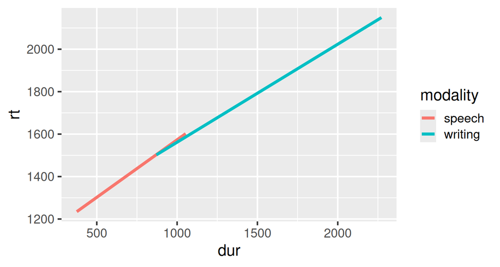

```r
ggplot(d_spellname, aes(x = dur,
                        y = rt,
                        colour = modality)) +
  stat_smooth(method = "lm", se = F)
```

- qualitative colours, labels, line colours
- sequential colours, shape outlines, line type
- filled shapes, hatching (shading with lines), line width

## Categorical Variables: `linetype`

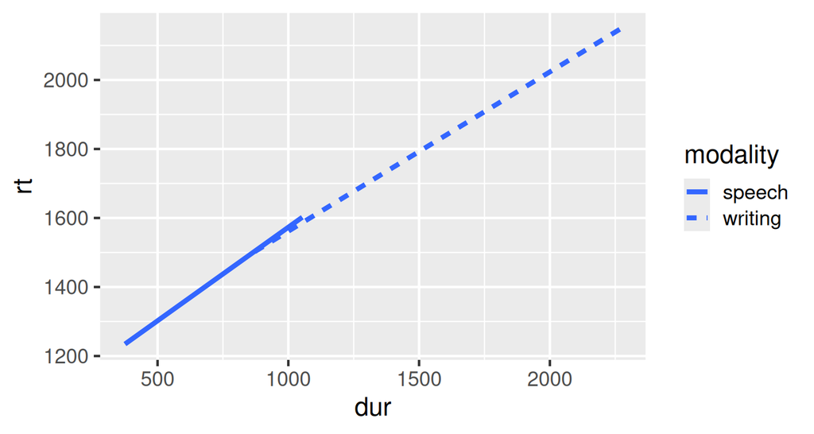

```r
ggplot(d_spellname, aes(x = dur,
                        y = rt,
                        linetype = modality)) +
  stat_smooth(method = "lm", se = F)
```

- qualitative colours, labels, line colours
- sequential colours, shape outlines, line type
- filled shapes, hatching (shading with lines), line width

## Categorical Variables: `size`

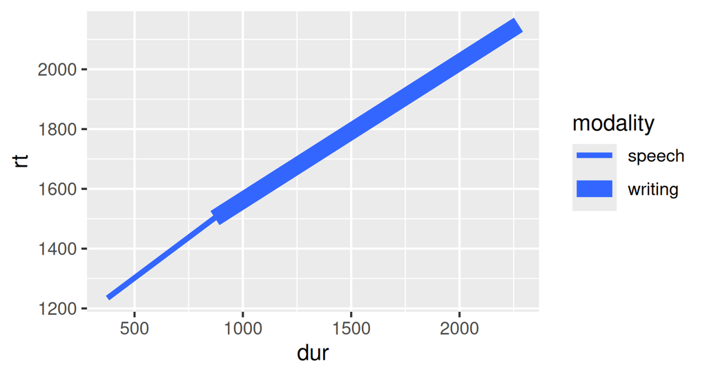

```r
ggplot(d_spellname, aes(x = dur,
                        y = rt,
                        size = modality)) +
  stat_smooth(method = "lm", se = F)
```

- qualitative colours, labels, line colours
- sequential colours, shape outlines, line type
- filled shapes, hatching (shading with lines), line width

## Continuous vs Categorical Variables

| **Variable Type** | **Typical Aesthetics** | **Visual Encoding** |
| --- | --- | --- |
| Continuous | x, y, size, color (gradient), alpha | magnitude, order |
| Categorical | x, shape, color (hue), fill | category, grouping |

## Visual Encoding Hierarchy

Which aesthetics are most effective for continuous vs categorical variables?

Principles of perceptual psychology and visual encoding theory are underpinning the Grammar of Graphics and `ggplot2`’s design choices (Cleveland & McGill, 1984; Wilkinson, 2005)

The human visual system perceives some encodings more accurately than others.

| **Accuracy (for continuous data)** | **Visual Encoding** | **Example in ggplot2** |
| --- | --- | --- |
| **Position on a common scale** | where a point lies along an axis | `aes(x, y)` |
| **Length / Size (1D)** | bar height, line length | `geom_bar()`, `aes(size)` |
| **Angle / Slope** | pie chart slices, line angle | `coord_polar()`, `geom_line()` |
| **Area (2D size)** | circle or bubble area | `aes(size)` (use carefully) |
| **Colour luminance / saturation** | brightness / lightness gradient | `scale_colour_gradient()` |
| **Colour hue** | qualitative differences | `scale_colour_brewer()` |
| **Shape / Symbol type** | triangle, circle, square | `aes(shape)` |
| **Spatial region / volume** | map regions, 3D volume | `geom_polygon()` |

- The top of the hierarchy (position, length) is best for continuous variables
- The bottom (hue, shape) is best for categorical variables

## Applied to `ggplot2`

**Continuous variables** prefer position / gradual encodings:

- `x`, `y`: continuous scales (most accurate)
- `size`: can work, avoid misleading area scaling
- `colour`: use gradients
- `alpha`: transparency can suggest intensity

Avoid using hue or shape: humans don’t perceive continuous changes in colour hue or shape as ordered or proportional.

**Categorical variables** prefer distinct encodings:

- `x`, `colour`, `fill`, `shape`, `linetype`
- Use qualitative palettes (e.g., `scale_colour_brewer(type = "qual")`)
- Don’t map numeric variables to hue unless they’re binned or converted to factors.

Each category should be visually distinct: no gradient or ordering implied.

## Which plot communicates difference better?

## Which plot communicates difference better?

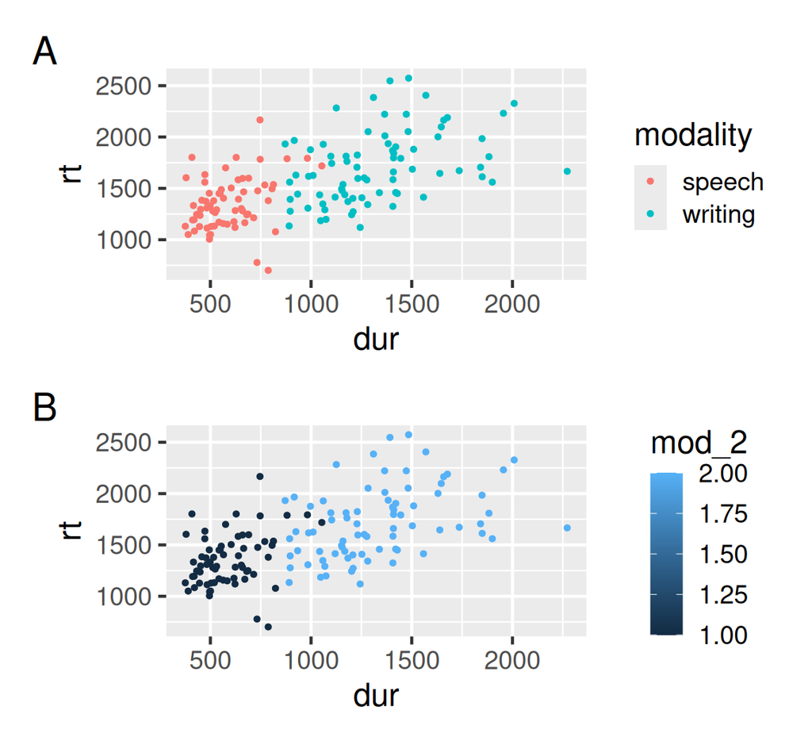

```r
# Modality as character
ggplot(d_spellname, aes(x = dur,
                        y = rt,
                        colour = modality)) +
  geom_point()

# Convert modality to numbers
d_spell_2 <- mutate(d_spellname,
                    mod_2 = as.numeric(factor(modality)))

ggplot(d_spell_2, aes(x = dur,
                          y = rt,
                          colour = mod_2)) +
  geom_point()
```

## Which plot shows quantity more precisely?

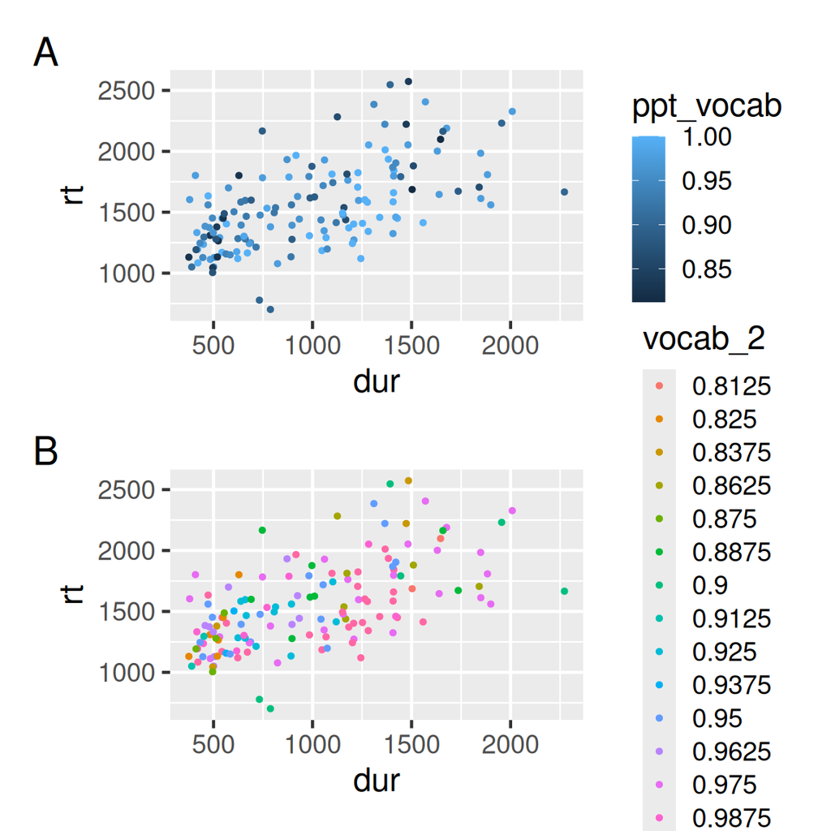

```r
# ppt_vocab as numeric
ggplot(d_spellname, aes(x = dur,
                        y = rt,
                        colour = ppt_vocab)) +
  geom_point()

# Convert ppt_vocab to characters
d_spell_2 <- mutate(d_spellname,
                        vocab_2 = as.character(ppt_vocab))

ggplot(d_spell_2, aes(x = dur,
                          y = rt,
                          colour = vocab_2)) +
  geom_point()
```

## Summary Hierarchy

| **Aesthetic** | **Best For** | **Why** |
| --- | --- | --- |
| **Position (x, y)** | Continuous | Most precise, linear mapping |
| **Length / Size** | Continuous | Perceived magnitude |
| **Color (lightness)** | Continuous | Suggests intensity or order |
| **Color (hue)** | Categorical | Distinct, unordered groups |
| **Shape / Linetype** | Categorical | Symbolic differences |
| **Fill / Alpha** | Either | Can show density or group separation |

## What does “Hue” mean?

Hue refers to the type of colour; what we usually mean when we say red, blue, green, yellow, etc.

It distinguishes different colours along the colour wheel, not how bright or dark they are.

- Hue = the colour family
- Lightness / Luminance
- Saturation = pure or intense

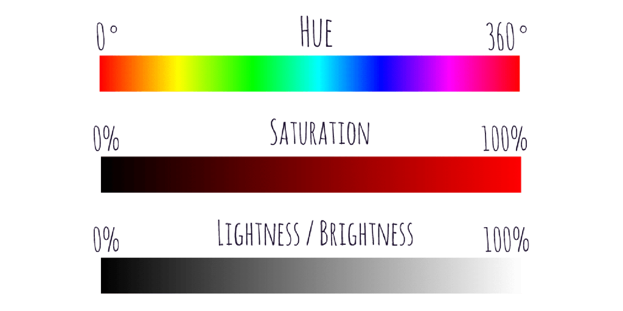

## In `ggplot2` terms

When you map a categorical variable to `colour` (or `fill`), `ggplot2` typically varies the hue:

Each penguin species (`palmerpenguins::penguins`) gets a different hue (blue, green, red).

This uses a qualitative palette, where hues are different but brightness is roughly equal.

There’s no order implied; just distinct color identities.

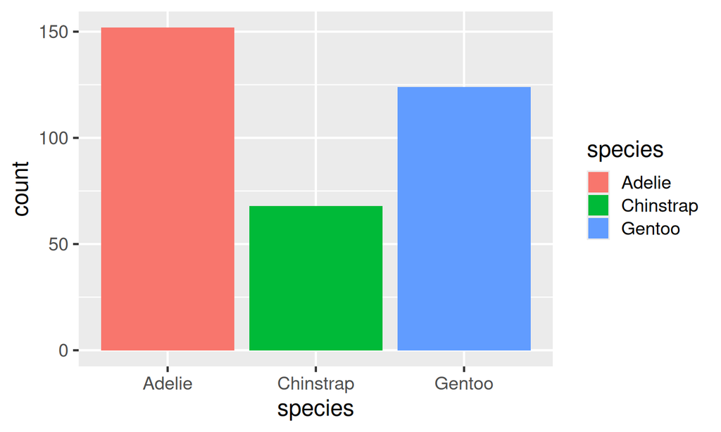

## Example: Hue vs. Brightness

| Type | Used For | Visual Meaning |
| --- | --- | --- |
| **Hue-based (qualitative)** | Categorical data | Different kinds |
| **Lightness-based (sequential)** | Continuous data | More ↔ Less |
| **Diverging (two hues)** | Continuous data around a midpoint | Below vs. above average |

## Aesthetics vs Attributes

Complete RMarkdown document **3_aaa.Rmd** for combining attributes and aesthetics.

## Reading

Next week we will continue with data visualisation in `ggplot2`. For basics of data visualisation in `ggplot2` see

- [Chapter 4 of Andrews (2021)](https://github.com/mark-andrews/ddsr/releases/download/v22.7.31/chapter_04_visualization.pdf)
- [Chapter 3 of Wickham & Grolemund (2016)](https://r4ds.had.co.nz/data-visualisation.html)
- [Chapters 11–13 of Wickham (2016)](https://ggplot2-book.org/scales-colour.html)

## Homework

Identify a dataset you would like to use for the formative assessment: post a description on our Teams channel.

Think about what you would like to visualise about these data:

- Combination of variables
- Variable types and appropriate aesthetics
- Raw data and / or summary statistics
- Look for appropriate visualisation tools [HERE](https://www.data-to-viz.com/)

## References

Andrews, M. (2021). *Doing data science in R: An introduction for Social Scientists*. SAGE Publications Ltd.

Cleveland, W. S., & McGill, R. (1984). Graphical perception: Theory, experimentation, and application to the development of graphical methods. *Journal of the American Statistical Association*, *79*(387), 531–554.

Wickham, H. (2010). A layered grammar of graphics. *Journal of Computational and Graphical Statistics*, *19*(1), 3–28.

Wickham, H. (2016). *ggplot2: Elegant graphics for data analysis*. Springer.

Wickham, H., & Grolemund, G. (2016). *R for data science: Import, tidy, transform, visualize, and model data*. O’Reilly Media, Inc.

Wilkinson, L. (2005). *The grammar of graphics* (2nd ed.). Springer.

Wong, B. (2010). Points of view: Design of data figures. *Nature Methods*, *7*(9), 665.